# Lab9

Dion, Julie, Mia, Vincent

11/8/2019

# Exercise 1: Take the review texts from the Women’s E-Commerce Clothing Reviews and turn them into a corpus. Change all upper case to lower case, remove punctuation, number and stopwords, stem the words, and delete any reviews with no text.

```r
wc <- read.csv(file = "Womens Clothing E-Commerce Reviews.csv",na.strings = c("", "NA"), stringsAsFactors = FALSE)

# Create Corpus
corpus <- VCorpus(VectorSource(wc$Review.Text))

clean_corpus <- function(corpus){
  corpus <- tm_map(corpus, content_transformer(tolower))
  corpus <- tm_map(corpus, removePunctuation)
  corpus <- tm_map(corpus, removeNumbers)
  corpus <- tm_map(corpus, removeWords, stopwords("en"))
  corpus <- tm_map(corpus, stemDocument)
  corpus <- tm_filter(corpus, FUN = function(x) content(x) != "NA")
  return(corpus)
}

ccleaned <- clean_corpus(corpus)
ccleaned
```

```
## <<VCorpus>>
## Metadata:  corpus specific: 0, document level (indexed): 0
## Content:  documents: 22641
```

```r
wc <- wc[!is.na(wc$Review.Text),] #Delete any reviews with no text in the dataframe.
```

```r
m <- as.matrix(DocumentTermMatrix(ccleaned))
v <- sort(colSums(m),decreasing=TRUE)
d <- data.frame(word = names(v),freq=v)
head(d, 10)
```

[output not shown]

# Exercise 1 Continued: DocumentTermMatrix(corpus) creates a document-term matrix with each entry counting how often the term corresponding with the column appears in the document corresponding with the row. DocumentTermMatrix does not return a standard matrix object, but one can transform it to matrix using as.matrix.

```r
dtm <- TermDocumentMatrix(ccleaned)
m <- as.matrix(dtm)
v <- sort(rowSums(m),decreasing=TRUE)
d <- data.frame(word = names(v),freq=v)
head(d, 10)
```

```
##        word  freq
## dress dress 12062
## love   love 11351
## fit     fit 11315
## size   size 10603
## look   look  9276
## top     top  8261
## wear   wear  8047
## like   like  7717
## color color  7191
## great great  6084
```

# Exercise 2: Make a histogram of the log of the document frequencies of all the terms in the corpus.

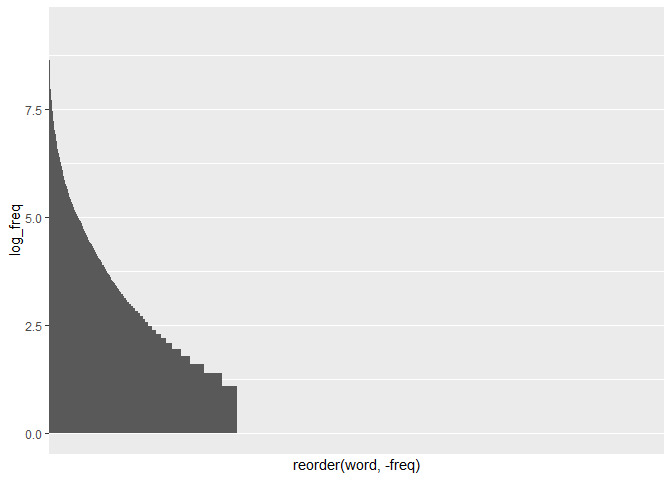

```r
hist_data <- d %>% mutate(log_freq = log(freq)) %>%
  mutate(perc_freq = freq / length(ccleaned) * 100)

p <- ggplot(hist_data, aes(x = reorder(word, -freq), y = log_freq)) + geom_bar(stat = "identity") + scale_x_discrete(breaks = seq(0, 10, by = 0.5))
p
```

# Exercise 2 Continued: For simplicity, let us constrain ourselves for the remainder of this lab to the 27 words that appear in no less than 10% and no more than 20% of all documents.

```r
m <- as.matrix(DocumentTermMatrix(ccleaned, control=list(bounds = list(global = c(0.1*length(ccleaned),0.2*length(ccleaned))))))
v <- sort(colSums(m),decreasing=TRUE)
d <- data.frame(word = names(v),freq=v)
length(d$word)
```

```
## [1] 27
```

```r
head(d,27)
```

```
##            word freq
## order     order 4983
## fabric   fabric 4852
## small     small 4574
## realli   realli 3922
## nice       nice 3800
## littl     littl 3773
## one         one 3694
## flatter flatter 3657
## will       will 3655
## tri         tri 3623
## beauti   beauti 3465
## soft       soft 3375
## comfort comfort 3277
## well       well 3237
## back       back 3180
## can         can 3136
## cute       cute 3024
## bought   bought 2981
## usual     usual 2886
## bit         bit 2874
## work       work 2858
## materi   materi 2816
## larg       larg 2793
## run         run 2777
## much       much 2702
## length   length 2630
## also       also 2575
```

# Exercise 3: Create a word cloud of these 27 (stemmed) words where the size of the words is determined by their document frequency. Hint: Use Google if you do not know how to make a word cloud in R.

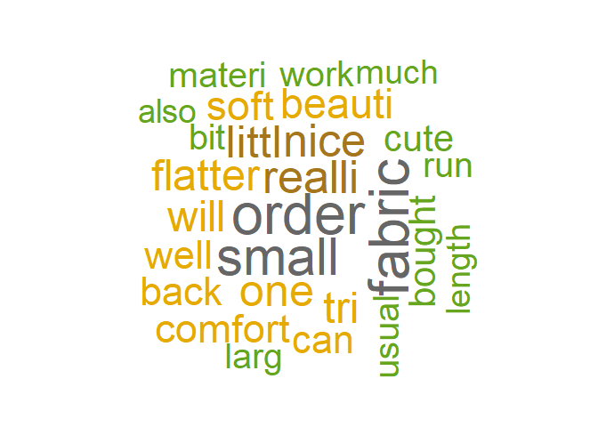

```r
set.seed(1234)
wordcloud(words = d$word, freq = d$freq,
          random.order=FALSE, scale=c(4,.5),
          colors=brewer.pal(8, "Dark2"))
```

# Exercise 4: Fit a logistic regression with as outcome whether the product is recommended by the reviewer. Use the TFIDF values with normalized term frequencies of the 27 words from the word cloud as predictors

```r
dtm_tfidf <- as.matrix(DocumentTermMatrix(ccleaned, control = list(bounds = list(global = c(0.1*length(ccleaned),0.2*length(ccleaned))), weighting = function(x) weightTfIdf(x, normalize = TRUE))))
dtm_tfidf <- as.data.frame(dtm_tfidf)
dtm_tfidf$outcome <- wc$Recommended.IND
```

```r
logit <- glm(outcome ~ ., data = dtm_tfidf, family=binomial)
summary(logit)
```

```
##
## Call:
## glm(formula = outcome ~ ., family = binomial, data = dtm_tfidf)
##
## Deviance Residuals:
##     Min       1Q   Median       3Q      Max
## -3.2915   0.2754   0.4896   0.6450   1.6245
##
## Coefficients:
##             Estimate Std. Error z value Pr(>|z|)
## (Intercept)  1.48341    0.07813  18.987  < 2e-16 ***
## also        -0.49128    0.05497  -8.937  < 2e-16 ***
## back        -0.82866    0.05160 -16.058  < 2e-16 ***
## beauti       0.26483    0.05979   4.429 9.45e-06 ***
## bit          0.61072    0.08362   7.304 2.79e-13 ***
## bought       0.39313    0.06947   5.659 1.52e-08 ***
## can          0.91626    0.08951  10.236  < 2e-16 ***
## comfort      1.37677    0.10742  12.817  < 2e-16 ***
## cute        -0.08469    0.05062  -1.673 0.094279 .
## fabric      -0.79723    0.05660 -14.086  < 2e-16 ***
## flatter      0.34944    0.06639   5.263 1.42e-07 ***
## larg        -0.27957    0.06168  -4.533 5.83e-06 ***
## length       0.40681    0.07377   5.514 3.50e-08 ***
## littl        0.83705    0.08532   9.811  < 2e-16 ***
## materi      -0.59313    0.05013 -11.833  < 2e-16 ***
## much        -0.41579    0.05132  -8.102 5.41e-16 ***
## nice         0.43277    0.06949   6.228 4.73e-10 ***
## one         -0.04403    0.05916  -0.744 0.456701
## order       -0.22075    0.06035  -3.658 0.000254 ***
## realli      -0.38265    0.05561  -6.881 5.93e-12 ***
## run          0.26626    0.07756   3.433 0.000597 ***
## small       -0.25552    0.06171  -4.141 3.46e-05 ***
## soft         1.04479    0.09285  11.252  < 2e-16 ***
## tri         -0.34230    0.05477  -6.250 4.11e-10 ***
## usual        0.18923    0.07631   2.480 0.013148 *
## well         0.29177    0.07069   4.127 3.67e-05 ***
## will         0.18868    0.06288   3.001 0.002694 **
## work        -0.21198    0.05330  -3.977 6.99e-05 ***
## ---
## Signif. codes:  0 '***' 0.001 '**' 0.01 '*' 0.05 '.' 0.1 ' ' 1
##
## (Dispersion parameter for binomial family taken to be 1)
##
##     Null deviance: 21423  on 22640  degrees of freedom
## Residual deviance: 19067  on 22613  degrees of freedom
## AIC: 19123
##
## Number of Fisher Scoring iterations: 6
```

# Exercise 5: Which (stemmed) words had a p-value of < 2e-16 in the logistic regression and seemed to indicate a negative review?

The words are “also”, “back”, “fabric”, and “materi”.